# **🏦 Credit Risk Prediction 💳💲**

INTRODUCTION

About Dataset

German Credit Risk

Context  
The original dataset contains 1000 entries with 20 categorial/symbolic attributes prepared by Prof. Hofmann. In this dataset, each entry represents a person who takes a credit by a bank. Each person is classified as good or bad credit risks according to the set of attributes. The link to the original dataset can be found below.

Acknowledgements  
Source: [German Credit Data](https://archive.ics.uci.edu/ml/datasets/South+German+Credit)

More information about the features are available on the website linked above.

RETRIEVING DATA

Import Libraries

```python
def warn(*args, **kwargs):
    pass
import warnings
warnings.warn = warn
```

```python
# Import libraries
import pandas as pd
import numpy as np
import matplotlib.pyplot as plt
import seaborn as sns
%matplotlib inline
```

Reading and Understanding Data

```python
# Reading data
df = pd.read_csv("D:/Pedoman/Portfolio/Credit Risk Prediction/german_credit_data_with_target.csv", sep=',')
df.head() # Displaying the first 5 lines of the dataset
```

|  | Unnamed: 0 | Age | Sex | Job | Housing | Saving accounts | Checking account | Credit amount | Duration | Purpose | Risk |
| --- | --- | --- | --- | --- | --- | --- | --- | --- | --- | --- | --- |
| 0 | 0 | 67 | male | 2 | own | NaN | little | 1169 | 6 | radio/TV | good |
| 1 | 1 | 22 | female | 2 | own | little | moderate | 5951 | 48 | radio/TV | bad |
| 2 | 2 | 49 | male | 1 | own | little | NaN | 2096 | 12 | education | good |
| 3 | 3 | 45 | male | 2 | free | little | little | 7882 | 42 | furniture/equipment | good |
| 4 | 4 | 53 | male | 2 | free | little | little | 4870 | 24 | car | bad |

```python
# Let's look at the dimension of the data
print(f'Data contain {df.shape[0]} records and {df.shape[1]} columns.')
```

```
Data contain 1000 records and 11 columns.
```

```python
# Get concise summary of the data
df.info()
```

```
<class 'pandas.core.frame.DataFrame'>
RangeIndex: 1000 entries, 0 to 999
Data columns (total 11 columns):
 #   Column            Non-Null Count  Dtype
---  ------            --------------  -----
 0   Unnamed: 0        1000 non-null   int64
 1   Age               1000 non-null   int64
 2   Sex               1000 non-null   object
 3   Job               1000 non-null   int64
 4   Housing           1000 non-null   object
 5   Saving accounts   817 non-null    object
 6   Checking account  606 non-null    object
 7   Credit amount     1000 non-null   int64
 8   Duration          1000 non-null   int64
 9   Purpose           1000 non-null   object
 10  Risk              1000 non-null   object
dtypes: int64(5), object(6)
memory usage: 86.1+ KB
```

DATA WRANGLING

```python
# Checking the unique values
df_uniques = pd.DataFrame([[i, len(df[i].unique())] for i in df.columns], columns=['Variable', 'Unique Values']).set_index('Variable')
df_uniques
```

| Variable | Unique Values |
| --- | --- |
| Unnamed: 0 | 1000 |
| Age | 53 |
| Sex | 2 |
| Job | 4 |
| Housing | 3 |
| Saving accounts | 5 |
| Checking account | 4 |
| Credit amount | 921 |
| Duration | 33 |
| Purpose | 8 |
| Risk | 2 |

```python
# Checking the duplicates
df.drop_duplicates(keep = 'first', inplace = True)
print(df.shape)
```

```
(1000, 11)
```

```python
# Renamed id columns
df = df.rename(columns={"Unnamed: 0": "Id"})
```

```python
# Check the number of missing values in each column
df.isna().sum()
```

```
Id                    0
Age                   0
Sex                   0
Job                   0
Housing               0
Saving accounts     183
Checking account    394
Credit amount         0
Duration              0
Purpose               0
Risk                  0
dtype: int64
```

```python
# Replace missing values with substituted values
for i in df.columns:
    if sum(df[i].isna()) != 0:
        if df[i].dtypes == "object":
            df[i]=df[i].fillna(df[i].mode().values[0])
        else:
            df[i]=df[i].fillna(df[i].mean())
```

```python
# Checking again the number of missing values in each column
df.isna().sum()
```

```
Id                  0
Age                 0
Sex                 0
Job                 0
Housing             0
Saving accounts     0
Checking account    0
Credit amount       0
Duration            0
Purpose             0
Risk                0
dtype: int64
```

```python
# Checking again the unique values
df_uniques = pd.DataFrame([[i, len(df[i].unique())] for i in df.columns], columns=['Variable', 'Unique Values']).set_index('Variable')
df_uniques
```

| Variable | Unique Values |
| --- | --- |
| Id | 1000 |
| Age | 53 |
| Sex | 2 |
| Job | 4 |
| Housing | 3 |
| Saving accounts | 4 |
| Checking account | 3 |
| Credit amount | 921 |
| Duration | 33 |
| Purpose | 8 |
| Risk | 2 |

```python
# Keep a copy our cleaned data
cleaned_data = df.copy()
```

EXPLORATORY DATA ANALYSIS

Distribution of Target Variable

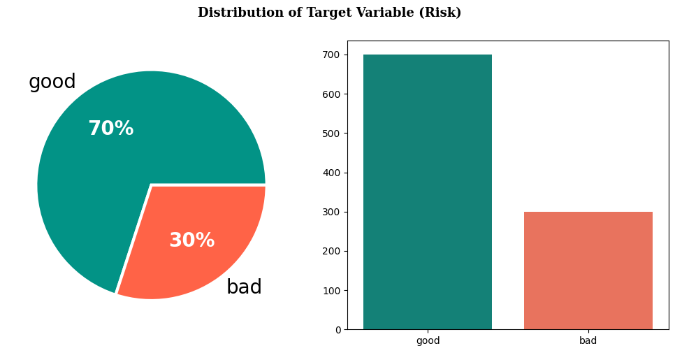

```
good    700
bad     300
Name: Risk, dtype: int64
```

```python
fig, axs = plt.subplots(1, 2, figsize=(10, 5))

colors = ['#029386','#ff6347']
color_dict = dict({'good':'#029386', 'bad':'#ff6347'})
# Pie Chart
# Capture each of the return elements.
patches, texts, pcts = axs[0].pie(
    df['Risk'].value_counts(), labels = df['Risk'].value_counts().index, autopct='%1.0f%%', colors=colors,
    wedgeprops={'linewidth': 3.0, 'edgecolor': 'white'},
    textprops={'size': 20})
# Style just the percent values.
plt.setp(pcts, color='white', fontweight='bold')

# Bar Plot
risks = df.groupby('Risk').agg({'Risk':'count'}).rename({'Risk': 'Total'}, axis = 1)
risks = risks.sort_values(['Total'], ascending = (False)).reset_index()

ax = sns.barplot(data=risks, x="Risk", y="Total", palette=color_dict, ax=axs[1])
ax.set(xlabel=None, ylabel=None)

fig.suptitle("Distribution of Target Variable (Risk)", fontfamily='serif', fontsize=13, fontweight='bold', y=1)
plt.tight_layout()
plt.show()
df['Risk'].value_counts()
```

Distribution of Categorical Features

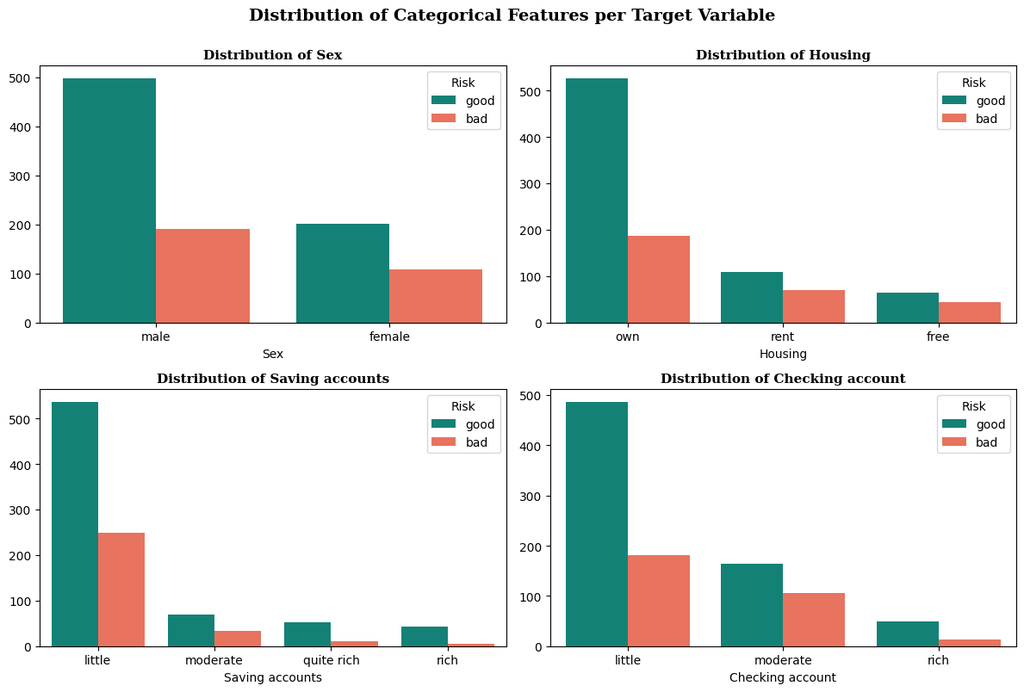

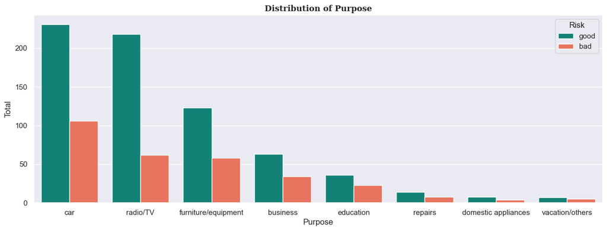

```python
# Each categorical features distribution per target variable

target_colors = dict({'good':'#029386', 'bad':'#ff6347'})
features = ['Sex','Housing','Saving accounts','Checking account']

fig, axs = plt.subplots(2, 2, figsize=(12, 8))
i = 0; j = 0
for n in range(0,len(features)):
    cf_data = df.groupby([features[n],'Risk']).agg({'Id':'count'}).rename({'Id': 'Total'}, axis = 1)
    cf_data = cf_data.sort_values(['Total'], ascending = (False)).reset_index()

    ax = sns.barplot(data=cf_data, x=features[n], y="Total", hue="Risk", palette=target_colors, ax=axs[i,j])
    ax.set_title("Distribution of "+features[n], fontfamily='serif', fontsize=11, fontweight='bold')
    ax.set(xlabel=features[n], ylabel=None)

    j = j+1
    if (j > 1):
        i = i+1
        j = 0

fig.suptitle('Distribution of Categorical Features per Target Variable', fontfamily='serif',fontsize=14, fontweight='bold', y=1)
plt.tight_layout()
plt.show()

cf_data = df.groupby(['Purpose','Risk']).agg({'Id':'count'}).rename({'Id': 'Total'}, axis = 1)
cf_data = cf_data.sort_values(['Total'], ascending = (False)).reset_index()

sns.set(rc = {'figure.figsize': (15, 5)})
ax = sns.barplot(data=cf_data, x="Purpose", y="Total", hue="Risk", palette=target_colors)
ax.set_title("Distribution of Purpose", fontfamily='serif', fontsize=12, fontweight='bold')
```

Distribution of Numerical Features per Target Variable

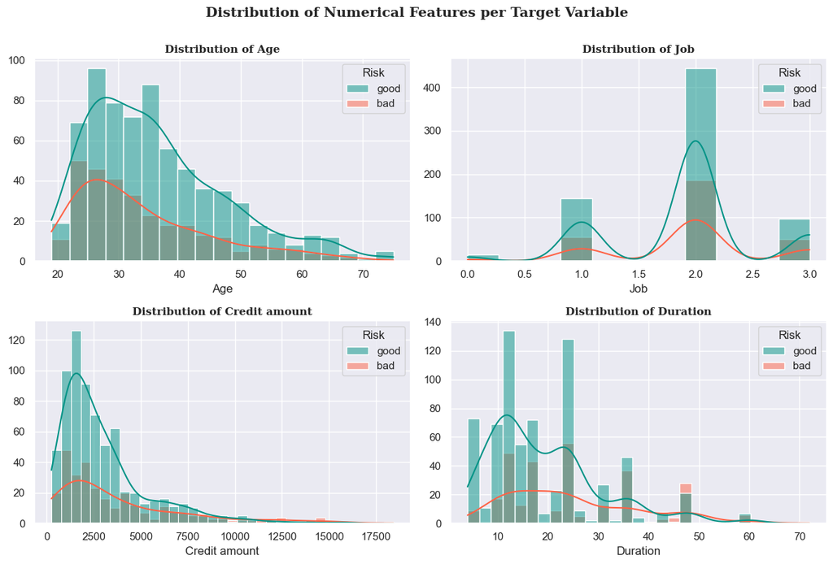

```python
# Each numerical features distribution per target variable

target_colors = dict({'good':'#029386', 'bad':'#ff6347'})
features = ['Age','Job','Credit amount','Duration']

fig, axs = plt.subplots(2, 2, figsize=(12, 8))
i = 0; j = 0
for n in range(0,len(features)):
    ax = sns.histplot(data=df, x=features[n], hue="Risk", kde=True, palette=target_colors, ax=axs[i,j])
    ax.set_title("Distribution of "+features[n], fontfamily='serif', fontsize=11, fontweight='bold')
    ax.set(xlabel=features[n], ylabel=None)

    j = j+1
    if (j > 1):
        i = i+1
        j = 0

fig.suptitle('Distribution of Numerical Features per Target Variable', fontfamily='serif', fontsize=14, fontweight='bold', y=1)
plt.tight_layout()
plt.show()
```

Total Distribution of Numerical Features

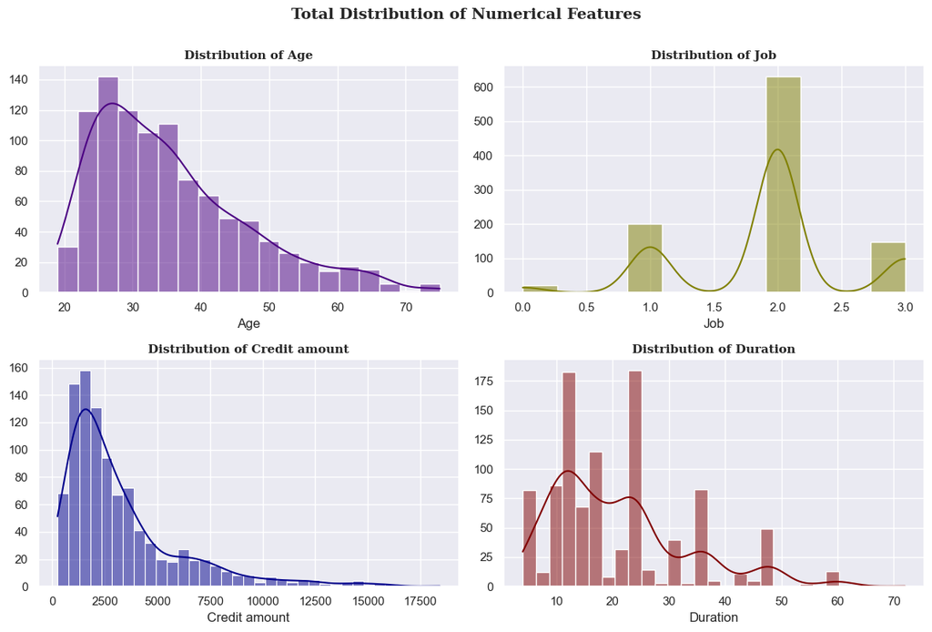

```python
colors_dict = dict({'Age':'#4b0082', 'Job':'#808000', 'Credit amount':'#00008b', 'Duration':'#800000'})
features = ['Age','Job','Credit amount','Duration']

fig, axs = plt.subplots(2, 2, figsize=(12, 8))
i = 0; j = 0
for n in range(0,len(features)):
    ax = sns.histplot(data=df, x=features[n], kde=True, color=colors_dict[features[n]], ax=axs[i,j])
    ax.set_title("Distribution of "+features[n], fontfamily='serif', fontsize=11, fontweight='bold')
    ax.set(xlabel=features[n], ylabel=None)

    j = j+1
    if (j > 1):
        i = i+1
        j = 0

fig.suptitle('Total Distribution of Numerical Features', fontfamily='serif', fontsize=14, fontweight='bold', y=1)
plt.tight_layout()
plt.show()
```

Box Plot of Features

```python
sns.set_style('white')
sns.set_context('notebook')
sns.set_palette('dark')
```

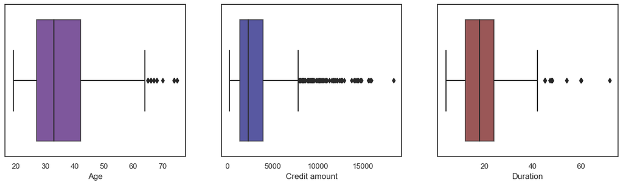

```python
colors_dict = dict({'Age':'#4b0082', 'Credit amount':'#00008b', 'Duration':'#800000'})
features = ['Age','Credit amount','Duration']

fig, axs = plt.subplots(1, 3, figsize=(16, 4))
j = 0
for n in range(0,len(features)):
    ax = sns.boxplot(data=df, x=features[n], color=colors_dict[features[n]], boxprops=dict(alpha=.7), ax=axs[j])
    j = j+1

plt.show()
```

Pair Plot of Features

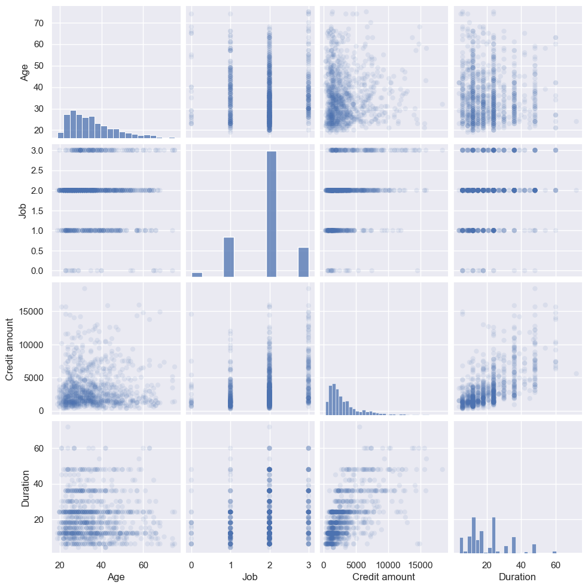

```python
sns.set_context('talk')
sns.set(rc = {'figure.figsize': (2, 1)})
# Drop unused columns
feat_df = df.drop('Id', axis=1)
sns.pairplot(feat_df, plot_kws=dict(alpha=.1, edgecolor='none'))
```

FEATURE ENGINEERING AND VARIABLE TRANSFORMATION

Feature Encoding

```python
# Drop unused variables
df = df.drop('Id', axis=1)
```

```python
df.Risk.value_counts()
```

```
good    700
bad     300
Name: Risk, dtype: int64
```

Scikit learn classifiers won't accept a sparse matrix for the prediction column. Thus, either `LabelBinarizer` needs to be used to convert the activity labels to integers.  
Use `LabelBinarizer` to fit_transform the "Risk" column, and look at binary values.

```python
from sklearn.preprocessing import LabelBinarizer

lb = LabelBinarizer()
df['Risk'] = lb.fit_transform(df.Risk)
df['Risk'].sample(5)
```

```
349    0
594    0
153    1
348    1
968    1
Name: Risk, dtype: int32
```

```python
target_variables = ['Risk']
[[i, list(df[i].unique())] for i in target_variables]
```

```
[['Risk', [1, 0]]]
```

```python
ordinal_variables = ['Job']
[[i, list(df[i].unique())] for i in ordinal_variables]
```

```
[['Job', [2, 1, 3, 0]]]
```

```python
# Get the categorical variables
categorical_variables = list(df_uniques[(8 >= df_uniques['Unique Values']) & (df_uniques['Unique Values'] > 1)].index)
categorical_variables = list(set(categorical_variables) - set(ordinal_variables) - set(target_variables))
[[i, list(df[i].unique())] for i in categorical_variables]
```

```
[['Housing', ['own', 'free', 'rent']],
 ['Checking account', ['little', 'moderate', 'rich']],
 ['Purpose',
  ['radio/TV',
   'education',
   'furniture/equipment',
   'car',
   'business',
   'domestic appliances',
   'repairs',
   'vacation/others']],
 ['Sex', ['male', 'female']],
 ['Saving accounts', ['little', 'quite rich', 'rich', 'moderate']]]
```

```python
# Get the numerical variables
numeric_variables = list(set(df.columns) - set(categorical_variables) - set(ordinal_variables) - set(target_variables))
numeric_variables
```

```
['Duration', 'Age', 'Credit amount']
```

```python
df = pd.get_dummies(df, columns = categorical_variables)
```

```python
df.describe().T
```

|  | count | mean | std | min | 25% | 50% | 75% | max |
| --- | --- | --- | --- | --- | --- | --- | --- | --- |
| Age | 1000.0 | 35.546 | 11.375469 | 19.0 | 27.0 | 33.0 | 42.00 | 75.0 |
| Job | 1000.0 | 1.904 | 0.653614 | 0.0 | 2.0 | 2.0 | 2.00 | 3.0 |
| Credit amount | 1000.0 | 3271.258 | 2822.736876 | 250.0 | 1365.5 | 2319.5 | 3972.25 | 18424.0 |
| Duration | 1000.0 | 20.903 | 12.058814 | 4.0 | 12.0 | 18.0 | 24.00 | 72.0 |
| Risk | 1000.0 | 0.700 | 0.458487 | 0.0 | 0.0 | 1.0 | 1.00 | 1.0 |
| Housing_free | 1000.0 | 0.108 | 0.310536 | 0.0 | 0.0 | 0.0 | 0.00 | 1.0 |
| Housing_own | 1000.0 | 0.713 | 0.452588 | 0.0 | 0.0 | 1.0 | 1.00 | 1.0 |
| Housing_rent | 1000.0 | 0.179 | 0.383544 | 0.0 | 0.0 | 0.0 | 0.00 | 1.0 |
| Checking account_little | 1000.0 | 0.668 | 0.471167 | 0.0 | 0.0 | 1.0 | 1.00 | 1.0 |
| Checking account_moderate | 1000.0 | 0.269 | 0.443662 | 0.0 | 0.0 | 0.0 | 1.00 | 1.0 |
| Checking account_rich | 1000.0 | 0.063 | 0.243085 | 0.0 | 0.0 | 0.0 | 0.00 | 1.0 |
| Purpose_business | 1000.0 | 0.097 | 0.296106 | 0.0 | 0.0 | 0.0 | 0.00 | 1.0 |
| Purpose_car | 1000.0 | 0.337 | 0.472921 | 0.0 | 0.0 | 0.0 | 1.00 | 1.0 |
| Purpose_domestic appliances | 1000.0 | 0.012 | 0.108940 | 0.0 | 0.0 | 0.0 | 0.00 | 1.0 |
| Purpose_education | 1000.0 | 0.059 | 0.235743 | 0.0 | 0.0 | 0.0 | 0.00 | 1.0 |
| Purpose_furniture/equipment | 1000.0 | 0.181 | 0.385211 | 0.0 | 0.0 | 0.0 | 0.00 | 1.0 |
| Purpose_radio/TV | 1000.0 | 0.280 | 0.449224 | 0.0 | 0.0 | 0.0 | 1.00 | 1.0 |
| Purpose_repairs | 1000.0 | 0.022 | 0.146757 | 0.0 | 0.0 | 0.0 | 0.00 | 1.0 |
| Purpose_vacation/others | 1000.0 | 0.012 | 0.108940 | 0.0 | 0.0 | 0.0 | 0.00 | 1.0 |
| Sex_female | 1000.0 | 0.310 | 0.462725 | 0.0 | 0.0 | 0.0 | 1.00 | 1.0 |
| Sex_male | 1000.0 | 0.690 | 0.462725 | 0.0 | 0.0 | 1.0 | 1.00 | 1.0 |
| Saving accounts_little | 1000.0 | 0.786 | 0.410332 | 0.0 | 1.0 | 1.0 | 1.00 | 1.0 |
| Saving accounts_moderate | 1000.0 | 0.103 | 0.304111 | 0.0 | 0.0 | 0.0 | 0.00 | 1.0 |
| Saving accounts_quite rich | 1000.0 | 0.063 | 0.243085 | 0.0 | 0.0 | 0.0 | 0.00 | 1.0 |
| Saving accounts_rich | 1000.0 | 0.048 | 0.213873 | 0.0 | 0.0 | 0.0 | 0.00 | 1.0 |

```python
df.head()
```

|  | Age | Job | Credit amount | Duration | Risk | Housing_free | Housing_own | Housing_rent | Checking account_little | Checking account_moderate | ... | Purpose_furniture/equipment | Purpose_radio/TV | Purpose_repairs | Purpose_vacation/others | Sex_female | Sex_male | Saving accounts_little | Saving accounts_moderate | Saving accounts_quite rich | Saving accounts_rich |
| --- | --- | --- | --- | --- | --- | --- | --- | --- | --- | --- | --- | --- | --- | --- | --- | --- | --- | --- | --- | --- | --- |
| 0 | 67 | 2 | 1169 | 6 | 1 | 0 | 1 | 0 | 1 | 0 | ... | 0 | 1 | 0 | 0 | 0 | 1 | 1 | 0 | 0 | 0 |
| 1 | 22 | 2 | 5951 | 48 | 0 | 0 | 1 | 0 | 0 | 1 | ... | 0 | 1 | 0 | 0 | 1 | 0 | 1 | 0 | 0 | 0 |
| 2 | 49 | 1 | 2096 | 12 | 1 | 0 | 1 | 0 | 1 | 0 | ... | 0 | 0 | 0 | 0 | 0 | 1 | 1 | 0 | 0 | 0 |
| 3 | 45 | 2 | 7882 | 42 | 1 | 1 | 0 | 0 | 1 | 0 | ... | 1 | 0 | 0 | 0 | 0 | 1 | 1 | 0 | 0 | 0 |
| 4 | 53 | 2 | 4870 | 24 | 0 | 1 | 0 | 0 | 1 | 0 | ... | 0 | 0 | 0 | 0 | 0 | 1 | 1 | 0 | 0 | 0 |

5 rows × 25 columns

Variable Transformation

Skew Variables

```python
# Create a list of numerical variables to check for skewing
skew_limit = 0.5 # define a limit above which we will log transform
skew_vals = df[numeric_variables].skew()
```

```python
# Showing the skewed columns
skew_cols = (skew_vals
             .sort_values(ascending=False)
             .to_frame()
             .rename(columns={0:'Skew'})
             .query('abs(Skew) > {}'.format(skew_limit)))

skew_cols
```

|  | Skew |
| --- | --- |
| Credit amount | 1.949628 |
| Duration | 1.094184 |
| Age | 1.020739 |

Distribution of Numerical Values

```
array([[<AxesSubplot: title={'center': 'Duration'}>,
        <AxesSubplot: title={'center': 'Age'}>],
       [<AxesSubplot: title={'center': 'Credit amount'}>,
        <AxesSubplot: >]], dtype=object)
```

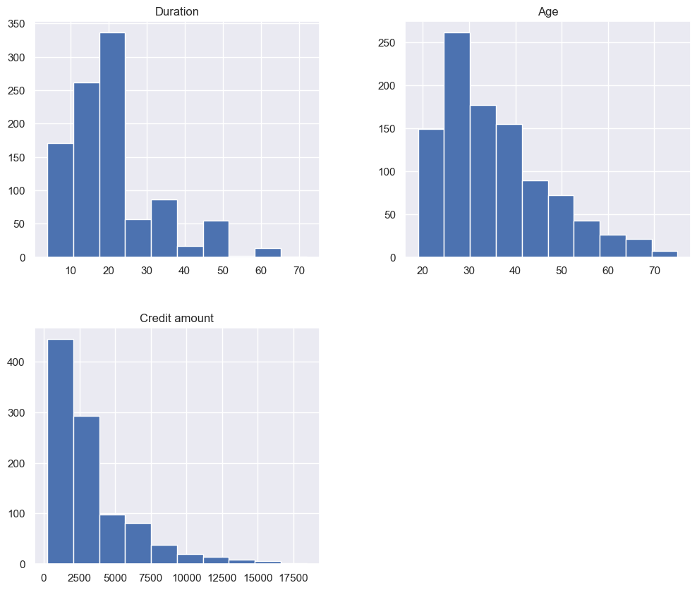

```python
# Distribution of numerical values
df[numeric_variables].hist(figsize=(12, 10))
```

Log Transforming Skew Variables

```python
# Let's look at what happens to these features, when we apply np.log1p visually.

def logTransform(field):
    for i in field:
        # Create two "subplots" and a "figure" using matplotlib
        fig, (ax_before, ax_after) = plt.subplots(1, 2, figsize=(8, 4))

        # Create a histogram on the "ax_before" subplot
        df[i].hist(ax=ax_before)

        # Apply a log transformation (numpy syntax) to this column
        df[i].apply(np.log1p).hist(ax=ax_after)

        # Formatting of titles etc. for each subplot
        ax_before.set(title='before np.log1p', ylabel='frequency', xlabel='value')
        ax_after.set(title='after np.log1p', ylabel='frequency', xlabel='value')
        fig.suptitle('Field "{}"'.format(i))
```

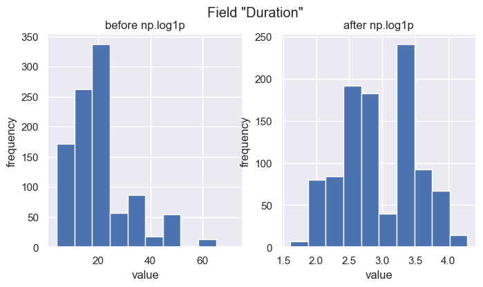

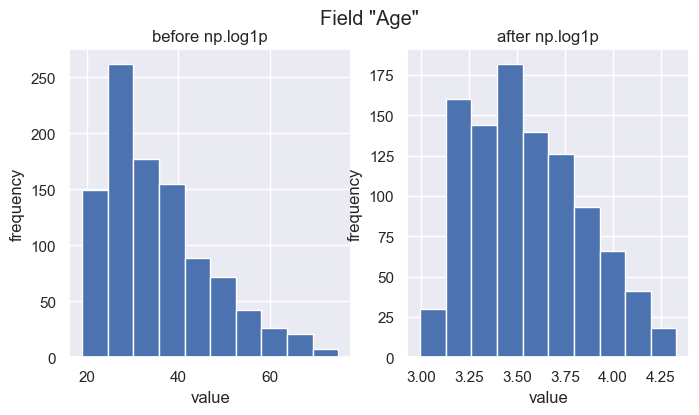

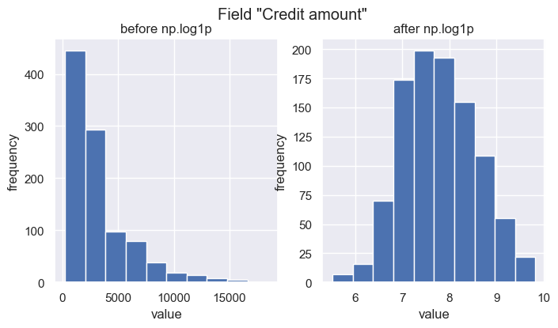

```python
logTransform(numeric_variables)
```

We can see the log of that data transform from a skewed dataset to a more normally distributed.

```python
# Perform the skew transformation:
for col in skew_cols.index.values:
    df[col] = df[col].apply(np.log1p)
```

Correlations Between The Dependent Variables

Calculate The Correlations

```python
# Calculate the correlation values
feature_cols = df.columns[:-1]
corr_values = df[feature_cols].corr()

# Simplify by emptying all the data below the diagonal
tril_index = np.tril_indices_from(corr_values)

# Make the unused values NaNs
for coord in zip(*tril_index):
    corr_values.iloc[coord[0], coord[1]] = np.NaN

# Stack the data and convert to a data frame
corr_values = (corr_values
               .stack()
               .to_frame()
               .reset_index()
               .rename(columns={'level_0':'feature1',
                                'level_1':'feature2',
                                0:'correlation'}))

# Get the absolute values for sorting
corr_values['abs_correlation'] = corr_values.correlation.abs()
```

Histogram of The Absolute Value Correlations

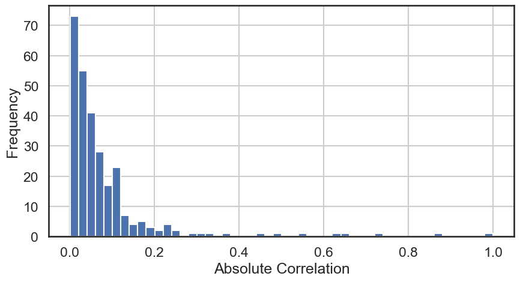

```python
sns.set_context('talk')
sns.set_style('white')

ax = corr_values.abs_correlation.hist(bins=50, figsize=(10, 5))
ax.set(xlabel='Absolute Correlation', ylabel='Frequency');
```

Identify The Most Correlated Variables (either positively or negatively)

```python
# The most highly correlated values
corr_values.sort_values('correlation', ascending=False).query('abs_correlation>0.6')
```

|  | feature1 | feature2 | correlation | abs_correlation |
| --- | --- | --- | --- | --- |
| 45 | Credit amount | Duration | 0.625916 | 0.625916 |
| 273 | Saving accounts_little | Saving accounts_moderate | -0.649422 | 0.649422 |
| 123 | Housing_own | Housing_rent | -0.735968 | 0.735968 |
| 156 | Checking account_little | Checking account_moderate | -0.860472 | 0.860472 |
| 266 | Sex_female | Sex_male | -1.000000 | 1.000000 |

MODEL DEVELOPMENT

Split Data into Train and Test Data Sets

- Split the data into train and test data sets. This can be done using any method, but consider using Scikit-learn's `StratifiedShuffleSplit` to maintain the same ratio of predictor classes.
- Regardless of the method used to split the data, compare the ratio of classes in both the train and test splits.

```python
from sklearn.model_selection import StratifiedShuffleSplit

# Get the split indexes
strat_shuf_split = StratifiedShuffleSplit(n_splits=1,
                                          test_size=0.3,
                                          random_state=42)

train_idx, test_idx = next(strat_shuf_split.split(df[feature_cols], df.Risk))

# Create the dataframes
X_train = df.loc[train_idx, feature_cols]
y_train = df.loc[train_idx, 'Risk']

X_test  = df.loc[test_idx, feature_cols]
y_test  = df.loc[test_idx, 'Risk']
```

```python
y_train.value_counts(normalize=True)
```

```
1    0.7
0    0.3
Name: Risk, dtype: float64
```

```python
y_test.value_counts(normalize=True)
```

```
1    0.7
0    0.3
Name: Risk, dtype: float64
```

Classifying Data Using Logistic Regression

Fit The Logistic Regression Model

- Fit a logistic regression model without any regularization using all of the features. Be sure to read the documentation about fitting a multi-class model so you understand the coefficient output. Store the model.
- Using cross validation to determine the hyperparameters and fit models using L1 and L2 regularization. Store each of these models as well. Note the limitations on multi-class models, solvers, and regularizations. The regularized models, in particular the L1 model, will probably take a while to fit.

```python
from sklearn.linear_model import LogisticRegression

# Standard logistic regression
lr = LogisticRegression(solver='liblinear').fit(X_train, y_train)
```

```python
from sklearn.linear_model import LogisticRegressionCV

# L1 regularized logistic regression
lr_l1 = LogisticRegressionCV(Cs=10, cv=4, penalty='l1', solver='liblinear').fit(X_train, y_train)
```

```python
# L2 regularized logistic regression
lr_l2 = LogisticRegressionCV(Cs=10, cv=4, penalty='l2', solver='liblinear').fit(X_train, y_train)
```

Store The Classification Results

- Predict and store the class for each model.
- Store the probability for the predicted class for each model.

```python
# Predict the class and the probability for each model
y_pred = list()
y_prob = list()

coeff_labels = ['lr', 'l1', 'l2']
coeff_models = [lr, lr_l1, lr_l2]

for lab,mod in zip(coeff_labels, coeff_models):
    y_pred.append(pd.Series(mod.predict(X_test), name=lab))
    y_prob.append(pd.Series(mod.predict_proba(X_test).max(axis=1), name=lab))

y_pred = pd.concat(y_pred, axis=1)
y_prob = pd.concat(y_prob, axis=1)

y_pred.head()
```

|  | lr | l1 | l2 |
| --- | --- | --- | --- |
| 0 | 0 | 0 | 0 |
| 1 | 1 | 1 | 1 |
| 2 | 1 | 1 | 1 |
| 3 | 1 | 1 | 1 |
| 4 | 1 | 1 | 1 |

```python
y_prob.head()
```

|  | lr | l1 | l2 |
| --- | --- | --- | --- |
| 0 | 0.967309 | 0.903292 | 0.690148 |
| 1 | 0.988355 | 0.972826 | 0.897968 |
| 2 | 0.979537 | 0.946704 | 0.868077 |
| 3 | 0.988212 | 0.951528 | 0.888397 |
| 4 | 0.971914 | 0.941775 | 0.800924 |

CLASSIFICATION ERROR METRICS

Calculate The Error Metrics

Calculate the following error metrics for each model :

- Accuracy
- Precision
- Recall
- F-score
- Confusion Matrix

Then, combine the multi-class metrics into a single value for each model.

```python
from sklearn.metrics import precision_recall_fscore_support as score
from sklearn.metrics import confusion_matrix, accuracy_score, roc_auc_score
from sklearn.preprocessing import label_binarize

metrics = list()
cm = dict()

for lab in coeff_labels:

    # Precision, recall, f1-score from the multi-class support function
    precision, recall, fscore, _ = score(y_test, y_pred[lab], average='weighted')

    # The usual way to calculate accuracy
    accuracy = accuracy_score(y_test, y_pred[lab])

    # ROC-AUC scores can be calculated by binarizing the data
    auc = roc_auc_score(label_binarize(y_test, classes=[0,1]),
              label_binarize(y_pred[lab], classes=[0,1]),
              average='weighted')

    # Last, the confusion matrix
    cm[lab] = confusion_matrix(y_test, y_pred[lab])

    metrics.append(pd.Series({'precision':precision, 'recall':recall,
                              'f1-score':fscore, 'accuracy':accuracy,
                              'auc':auc},
                             name=lab))

metrics = pd.concat(metrics, axis=1)
```

```python
metrics
```

|  | lr | l1 | l2 |
| --- | --- | --- | --- |
| precision | 1.0 | 1.0 | 1.0 |
| recall | 1.0 | 1.0 | 1.0 |
| f1-score | 1.0 | 1.0 | 1.0 |
| accuracy | 1.0 | 1.0 | 1.0 |
| auc | 1.0 | 1.0 | 1.0 |

Visualize The Confusion Matrix

- Display or plot the confusion matrix for each model.

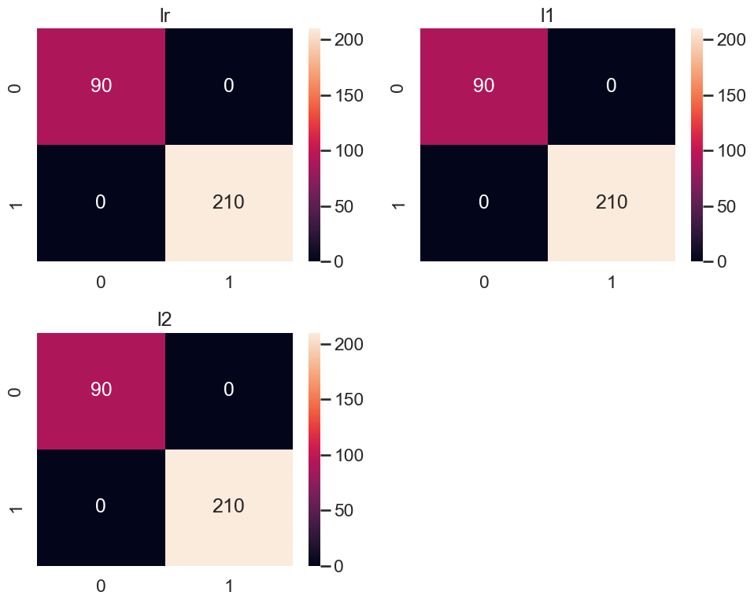

```python
fig, axList = plt.subplots(nrows=2, ncols=2)
axList = axList.flatten()
fig.set_size_inches(10, 8)

axList[-1].axis('off')

for ax,lab in zip(axList[:-1], coeff_labels):
    sns.heatmap(cm[lab], ax=ax, annot=True, fmt='d');
    ax.set(title=lab);

plt.tight_layout()
```